# Activitat 4: Anàlisi de la Variància i Repàs del Curs

# 5 Regressió logística

## 5.1 Model predictiu

Comencem creant la variable dicotòmica

```r
data_2015$High_adult_mortality <- ifelse(data_2015$Adult_mortality > median(data_2015$Adult_mortality), 1, 0)
```

Ara, ajustarem un model predictiu basat en la regressió logística amb la variable *High_adult_mortality* creada com a dependent de les altres variables esmenatdes.

```r
library(stats)
logistic_model <- glm(High_adult_mortality ~ Hepatitis_B + Measles + BMI + Polio + Diphtheria,
                      data = data_2015, family = binomial())
summary(logistic_model)
```

```
##
## Call:
## glm(formula = High_adult_mortality ~ Hepatitis_B + Measles +
##     BMI + Polio + Diphtheria, family = binomial(), data = data_2015)
##
## Coefficients:
##             Estimate Std. Error z value Pr(>|z|)
## (Intercept) 19.13411    3.68108   5.198 2.01e-07 ***
## Hepatitis_B  0.27621    0.12017   2.299  0.02153 *
## Measles     -0.05801    0.01916  -3.028  0.00246 **
## BMI         -0.30874    0.11132  -2.774  0.00554 **
## Polio       -0.12280    0.05862  -2.095  0.03619 *
## Diphtheria  -0.22305    0.12894  -1.730  0.08365 .
## ---
## Signif. codes:  0 '***' 0.001 '**' 0.01 '*' 0.05 '.' 0.1 ' ' 1
##
## (Dispersion parameter for binomial family taken to be 1)
##
##     Null deviance: 248.14  on 178  degrees of freedom
## Residual deviance: 149.03  on 173  degrees of freedom
## AIC: 161.03
##
## Number of Fisher Scoring iterations: 6
```

El model de regressió logística suggereix:

- *Hepatitis_B* (coeficient = 0.27621, p = 0.02153): positiu i significatiu, suggerint que un augment en la cobertura de vacunació contra l’Hepatitis B està associat amb un lleuger augment en la probabilitat de mortalitat adulta alta.
- *Measles* (coeficient = -0.05801, p = 0.00246): negatiu i significatiu, indicant que un augment en la cobertura de vacunació contra el xarampió està associat amb una reducció en la probabilitat de mortalitat adulta alta. Aquesta variable actua com un factor de protecció.
- *BMI* (coeficient = -0.30874, p = 0.00554): negatiu i significatiu, mostrant que un major índex de massa corporal està associat amb una menor probabilitat de mortalitat adulta alta. Aquest resultat podria indicar ser una variable protectora.
- *Polio* (coeficient = -0.12280, p = 0.03619): negatiu i significatiu, suggerint que una millor cobertura de vacunació contra la polio està associada amb una menor probabilitat de mortalitat adulta alta, funcionant com un factor de protecció.
- *Diphtheria* (coeficient = -0.22305, p = 0.08365): negatiu però no significatiu (p > 0.05). Suggereix una tendència on una millor cobertura de vacunació contra la diftèria podria reduir la probabilitat de mortalitat adulta alta.

En quant a la qualitat del model, la deviance residual ha disminuït de 248.14 a 149.03 després de l’ajust del model, indicant una millora significativa en l’ajust del model respecte al model nul. En relació a l’AIC (161.03), si en comparació al d’un model alternatiu fos més baix, suggeriria un millor ajust.

Per tenir una milor idea de quines variables són de protecció i quines de risc, explorem l’Odds Ràtio.

```r
odds_ratios <- exp(coef(logistic_model))

conf_int <- exp(confint(logistic_model))
odds_ratio_table <- cbind(OddsRatio = odds_ratios, ConfIntLow = conf_int[,1], ConfIntHigh = conf_int[,2])
print(odds_ratio_table)
```

```
##                OddsRatio   ConfIntLow  ConfIntHigh
## (Intercept) 2.040983e+08 2.824296e+05 5.898814e+11
## Hepatitis_B 1.318128e+00 1.084620e+00 1.752763e+00
## Measles     9.436392e-01 9.073974e-01 9.786366e-01
## BMI         7.343706e-01 5.840002e-01 9.070829e-01
## Polio       8.844381e-01 7.807246e-01 9.840588e-01
## Diphtheria  8.000735e-01 5.962856e-01 9.966918e-01
```

Els resultats del model de regressió logística indiquen que lavacunació contra l’hepatitis B (1.32) actua com a factor de risc lleuger, incrementant les probabilitats d’alta mortalitat adulta. En canvi, les vacunacions contra el xarampió, la polio i la diftèria, juntament amb un major índex de massa corporal (BMI), serveixen com factors de protecció, reduint les probabilitats de mortalitat adulta alta. Aquest últim factor molt probablement fa referència a un índex de massa corporal relacionat amb una bona alimentació.

## 5.2 Matriu de confusió

Calculem la matriu de confusió per analitzar la precisió del model

```r
predicted_probabilities <- predict(logistic_model, type = "response")

predicted_classes <- ifelse(predicted_probabilities >= 0.5, 1, 0)

conf_matrix <- table(Predicted = predicted_classes, Actual = data_2015$High_adult_mortality)

confusionMatrix(conf_matrix)
```

```
## Confusion Matrix and Statistics
##
##          Actual
## Predicted  0  1
##         0 75 24
##         1 15 65
##
##                Accuracy : 0.7821
##                  95% CI : (0.7144, 0.8402)
##     No Information Rate : 0.5028
##     P-Value [Acc > NIR] : 1.285e-14
##
##                   Kappa : 0.564
##
##  Mcnemar's Test P-Value : 0.2002
##
##             Sensitivity : 0.8333
##             Specificity : 0.7303
##          Pos Pred Value : 0.7576
##          Neg Pred Value : 0.8125
##              Prevalence : 0.5028
##          Detection Rate : 0.4190
##    Detection Prevalence : 0.5531
##       Balanced Accuracy : 0.7818
##
##        'Positive' Class : 0
##
```

# 6 ANOVA unifactorial

## 6.1 Visualització gràfica

```r
if (!requireNamespace("ggpubr", quietly = TRUE)) {
  install.packages("ggpubr")
}
library(ggpubr)

ggline(data_2015, x = "Region", y = "Life_expectancy",
       add = "mean_se",
       color = "Region",
       palette = "jco") +
  theme_minimal()
```

```
## `geom_line()`: Each group consists of only one observation.
## ℹ Do you need to adjust the group aesthetic?
```

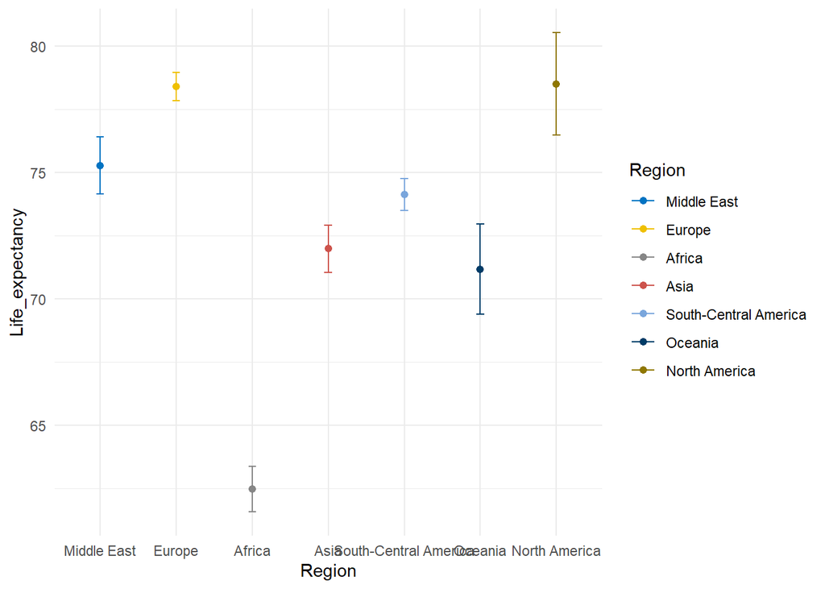

## 6.2 Hipòtesi nul·la i alternativa

Les hipòtesis per aquest ANOVA són:

Hipòtesi nul·la (H0): No hi ha diferències significatives en l’esperança de vida entre les diferents regions. Hipòtesi alternativa (H1): Hi ha almenys una regió que té una esperança de vida significativament diferent de les altres.

## 6.3 Model

```r
anova_model <- aov(Life_expectancy ~ Region, data = data_2015)

summary(anova_model)
```

```
##              Df Sum Sq Mean Sq F value Pr(>F)
## Region        6   6725  1120.8   45.96 <2e-16 ***
## Residuals   172   4195    24.4
## ---
## Signif. codes:  0 '***' 0.001 '**' 0.01 '*' 0.05 '.' 0.1 ' ' 1
```

L’ANOVA mostra que hi ha diferències estadísticament significatives en l’esperança de vida entre les regions (F value = 45.96, p-value < 2e-16). Aquest resultat indica que la regió té un impacte considerable en l’esperança de vida, rebutjant així la hipòtesi nul·la que afirma que no existeixen diferències significatives entre regions.

# 7 Comparacions múltiples

```r
library(stats)


comparison_results <- pairwise.t.test(data_2015$Life_expectancy, data_2015$Region,
                                      p.adjust.method = "bonferroni")

print(comparison_results)
```

```
##
##  Pairwise comparisons using t tests with pooled SD
##
## data:  data_2015$Life_expectancy and data_2015$Region
##
##                       Africa  Asia    Europe  Middle East North America Oceania
## Asia                  2.1e-12 -       -       -           -             -
## Europe                < 2e-16 8.8e-06 -       -           -             -
## Middle East           1.0e-13 0.93739 0.88331 -           -             -
## North America         3.4e-06 0.66064 1.00000 1.00000     -             -
## Oceania               7.3e-06 1.00000 0.00056 0.85910     0.50309       -
## South-Central America < 2e-16 1.00000 0.00740 1.00000     1.00000       1.00000
##
## P value adjustment method: bonferroni
```

# 8 ANOVA multifactorial

```r
grouped_data <- data_2015 %>%
  group_by(Region, Economy_status_Developed) %>%
  summarise(Mean_Life_Expectancy = mean(Life_expectancy, na.rm = TRUE))
print(grouped_data)
```

```
## # A tibble: 12 × 3
## # Groups:   Region [7]
##    Region                Economy_status_Developed Mean_Life_Expectancy
##    <chr>                                    <int>                <dbl>
##  1 Africa                                       0                 62.5
##  2 Asia                                         0                 71.5
##  3 Asia                                         1                 83.8
##  4 Europe                                       0                 74.3
##  5 Europe                                       1                 79.9
##  6 Middle East                                  0                 74.7
##  7 Middle East                                  1                 82.1
##  8 North America                                0                 74.9
##  9 North America                                1                 80.3
## 10 Oceania                                      0                 68.8
## 11 Oceania                                      1                 82.0
## 12 South-Central America                        0                 74.1
```

## 8.1 Càlcul del model

```r
anova_model <- aov(Life_expectancy ~ Region * Economy_status_Developed, data = data_2015)

summary(anova_model)
```

```
##                                  Df Sum Sq Mean Sq F value   Pr(>F)
## Region                            6   6725  1120.8  54.364  < 2e-16 ***
## Economy_status_Developed          1    645   645.1  31.288 8.93e-08 ***
## Region:Economy_status_Developed   4    107    26.6   1.292    0.275
## Residuals                       167   3443    20.6
## ---
## Signif. codes:  0 '***' 0.001 '**' 0.01 '*' 0.05 '.' 0.1 ' ' 1
```

L’ANOVA mostra que tant la regió com l’estatus de desenvolupament tenen efectes significatius en l’esperança de vida, amb p-valors molt baixos indicant fortes diferències. No obstant això, l’interacció entre aquests dos factors no és estadísticament significativa, suggerint que l’impacte de l’estatus de desenvolupament sobre l’esperança de vida no varia substancialment entre regions